# COVID-19 By Country

August 02, 2022 16:00:42

**The COVID-19 Econometric Modeling Team**

Cynthia L. Gong, PharmD, PhD  
Nadine K. Zawadzki, MPH (PhD Cand.)  
Roy S. Zawadzki, BS  
Sang K. Cho, PharmD, MPH, PhD  
Joel W. Hay, PhD

| Document Table of Contents |
| --- |
| Newly Reported Patients By Total Confirmed Patients |
| Log of Cumulative Reported Patients |
| Plots by Country with Ridge Regression Models |
| Mathematical Presentation of COVID-19 Transmission Dynamics |
| Calculating Deaths per 1% Increase in Unemployment |
| Calculating Deaths per Million |

[**Please Take Our COVID SURVEY! (Click Here)**](https://www.google.com/url?q=https%3A%2F%2Fusc.qualtrics.com%2Fjfe%2Fform%2FSV_9Qqhify98dXlyiF&sa=D&sntz=1&usg=AFQjCNG6ImRy3yxgZQarAFePHhPzgtvPpA)

# Newly Reported Patients By Total Confirmed Patients

### Cases

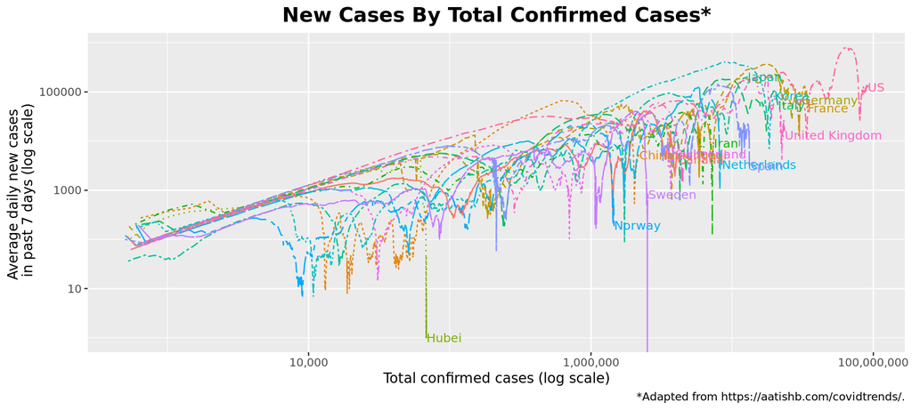

### Deaths

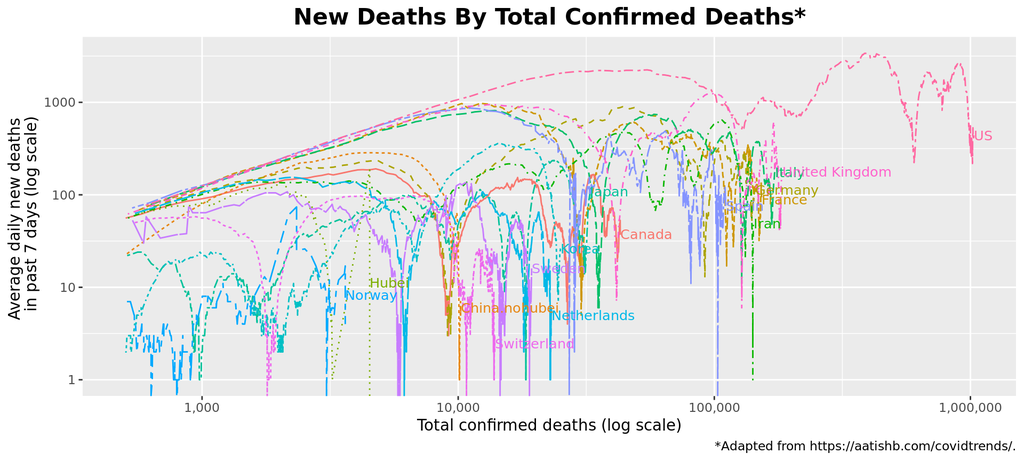

**CLICK HERE to view a mathematical presentation of COVID-19 transmission dynamics**

Back to top

# Log of Cumulative Reported Patients

### Cases

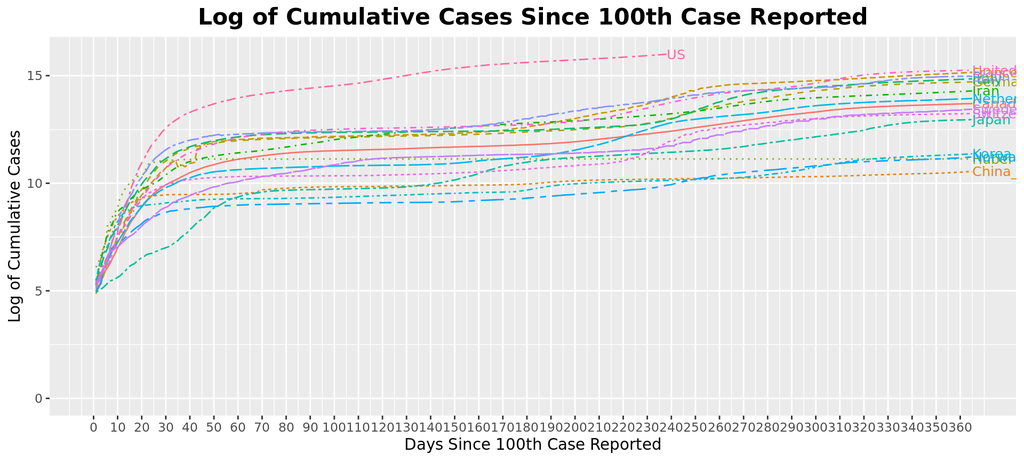

### Deaths

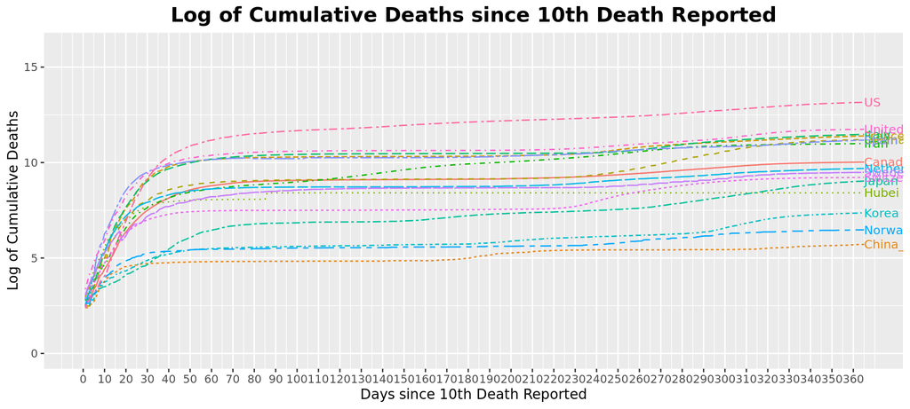

Back to top

# Plots by Country with Ridge Regression Models

- Figures are the first difference of ln(cumulative cases) or ln(cumulative deaths) since Day 0.
- Day 0 defined as day since 100th case reported or day since 10th death reported.
- Linear ridge regression models are fitted to the data as a function of time, time$^2$, time$^3$, time$^{1/2}$, time$^{1/3}$, and time$^{-1}$.

## Cases

### Global

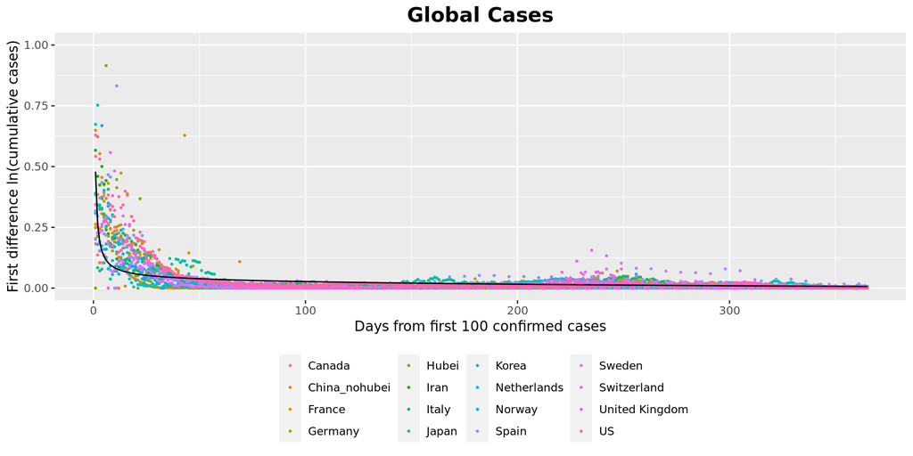

### Canada

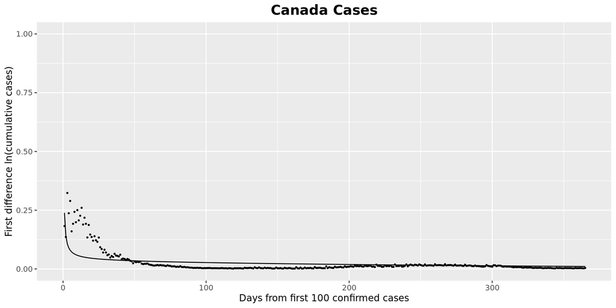

### China (excluding Hubei)

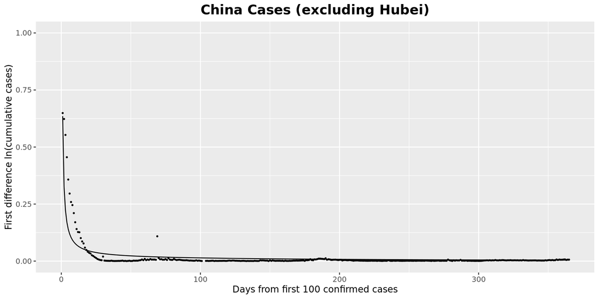

### France

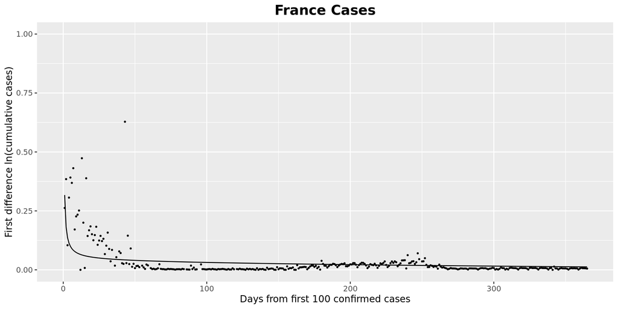

### Germany

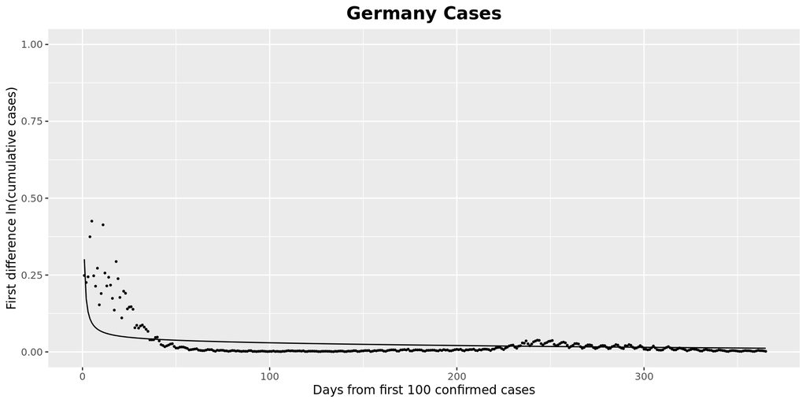

### Hubei

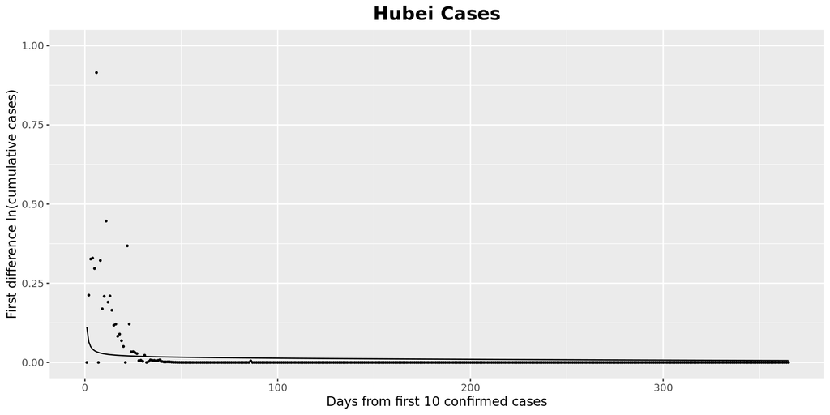

### Iran

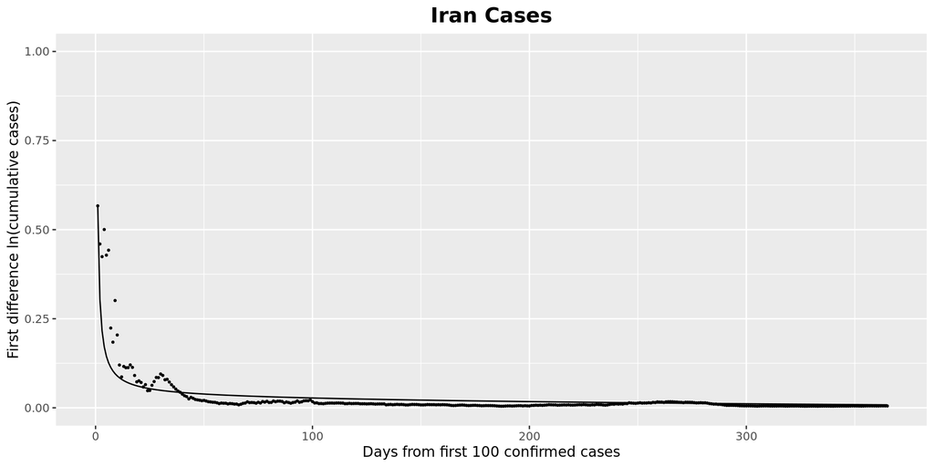

### Italy

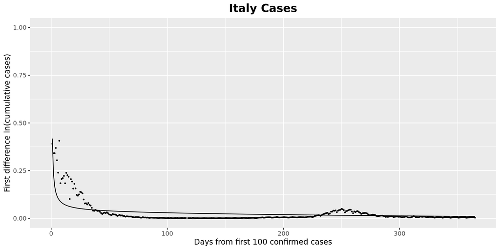

### Japan

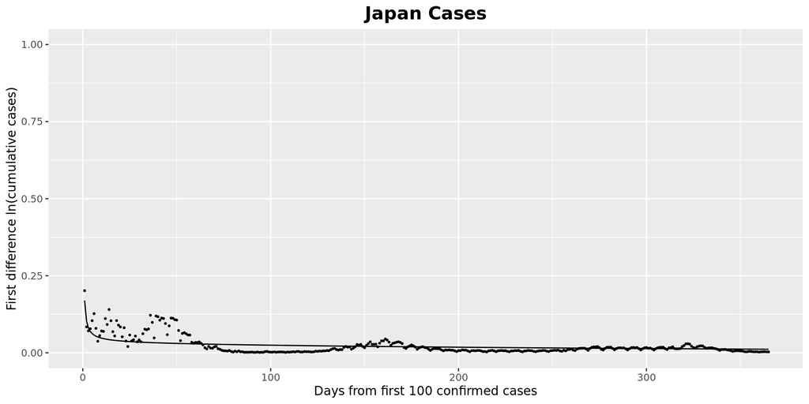

### South Korea

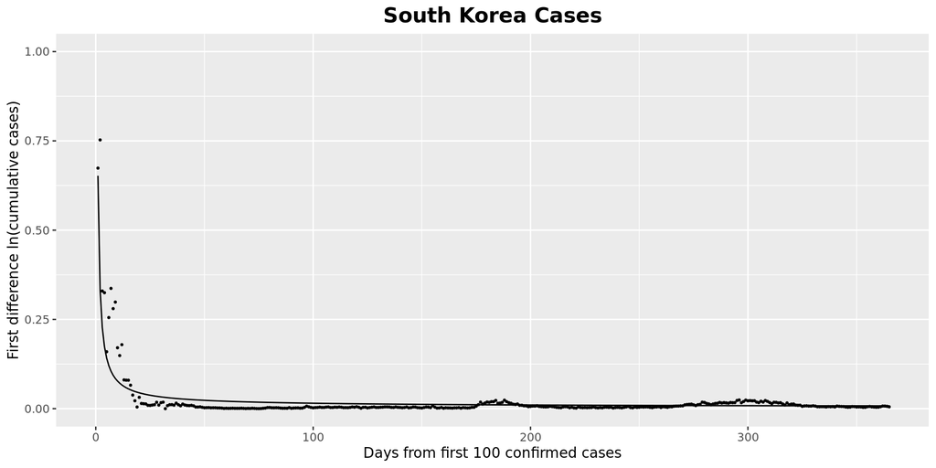

### Netherlands

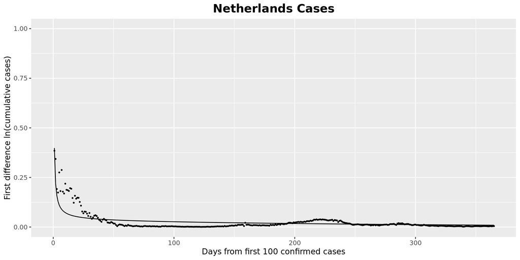

### Norway

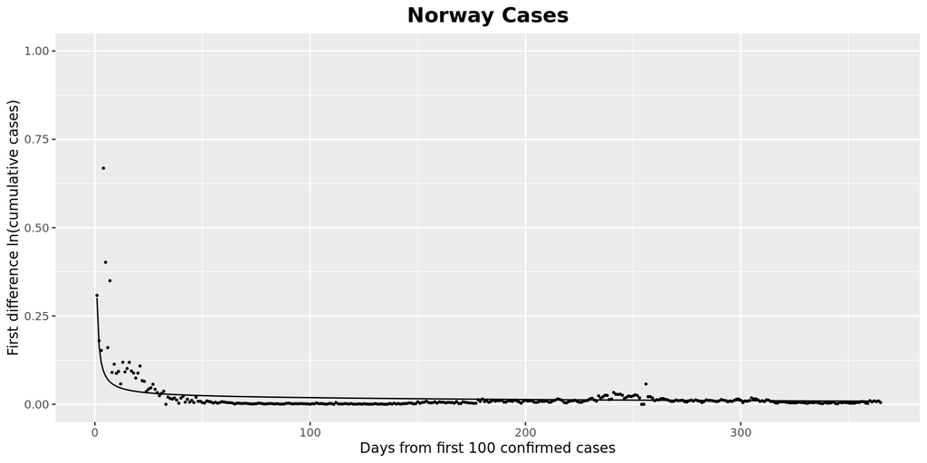

### Spain

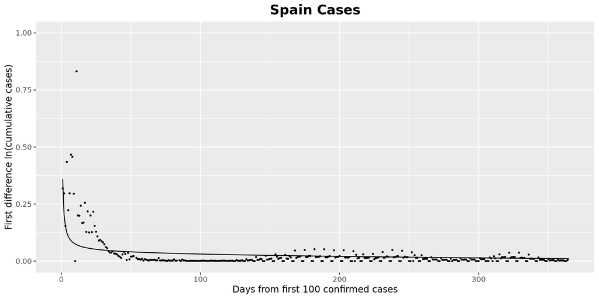

### Sweden

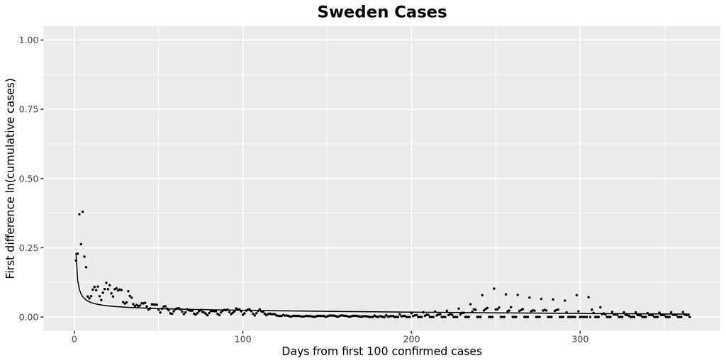

### Switzerland

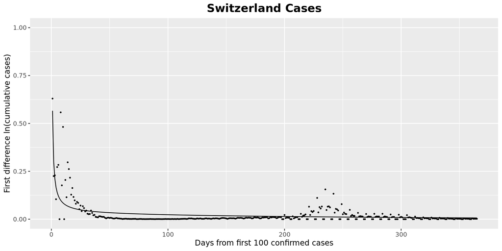

### United Kingdom

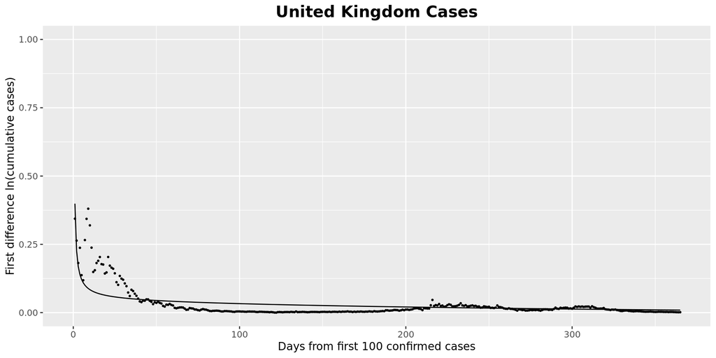

### United States

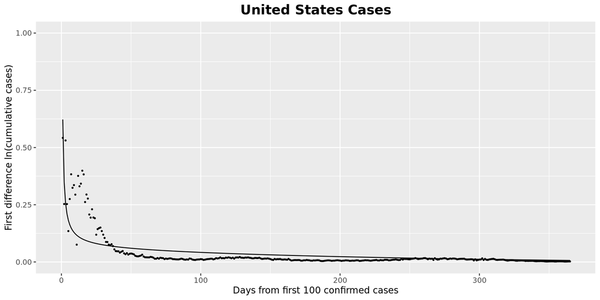

## Deaths

### Global

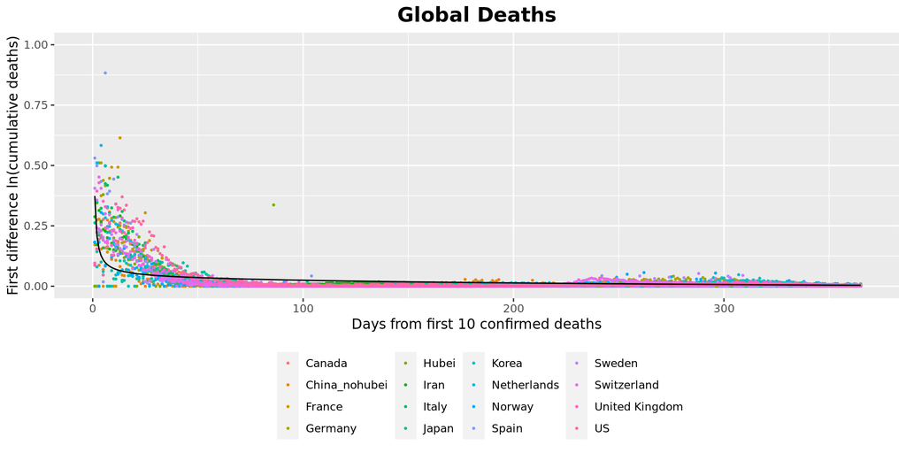

### Canada

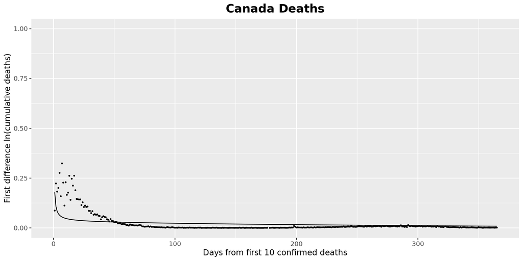

### China (excluding Hubei)

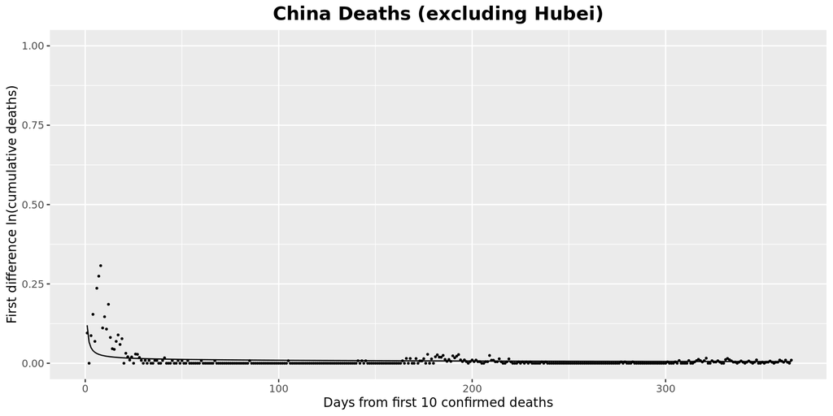

### France

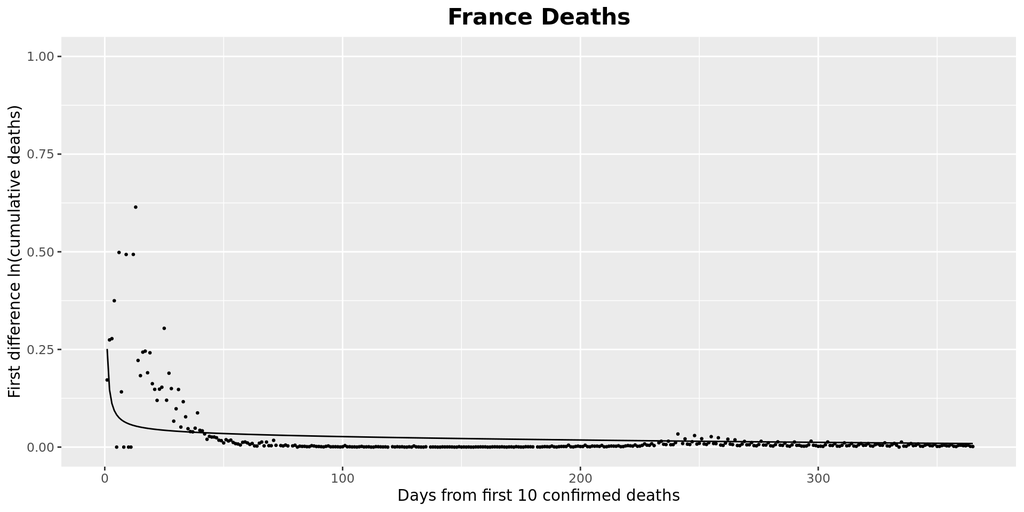

### Germany

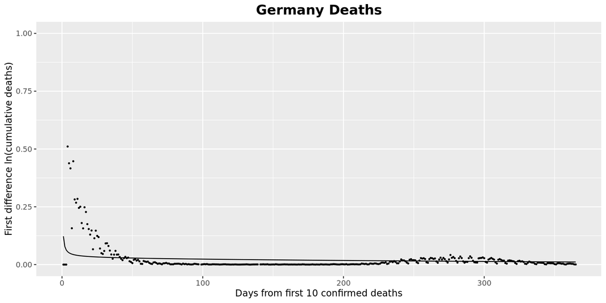

### Hubei

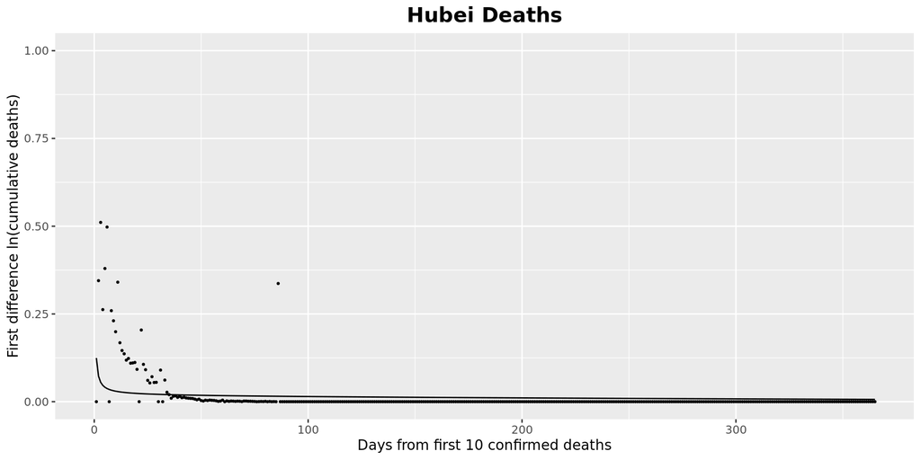

### Iran

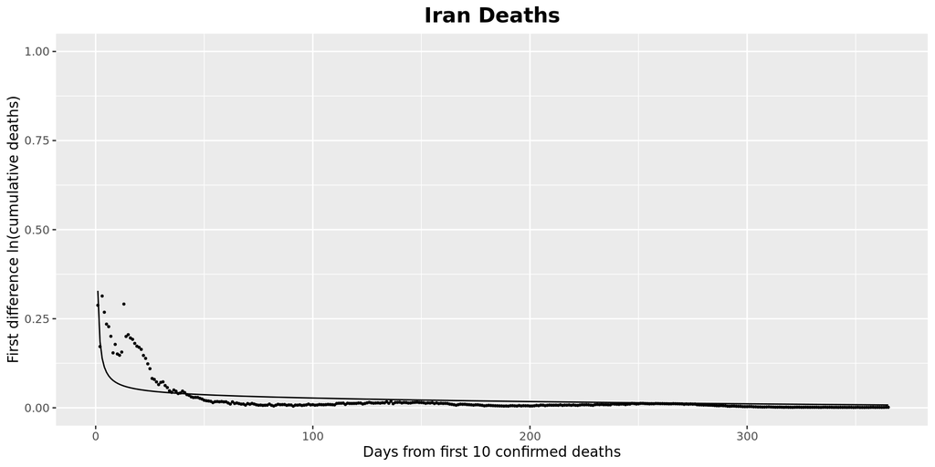

### Italy

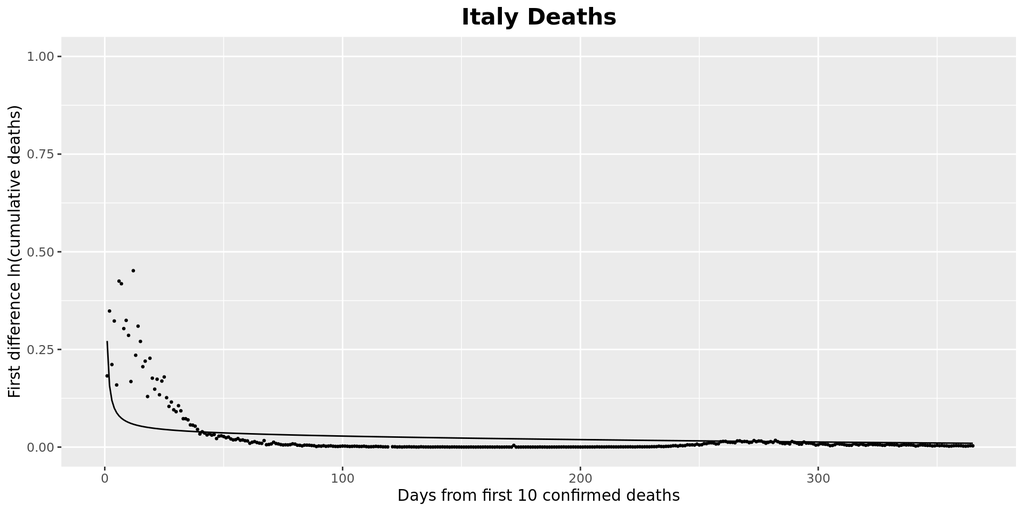

### Japan

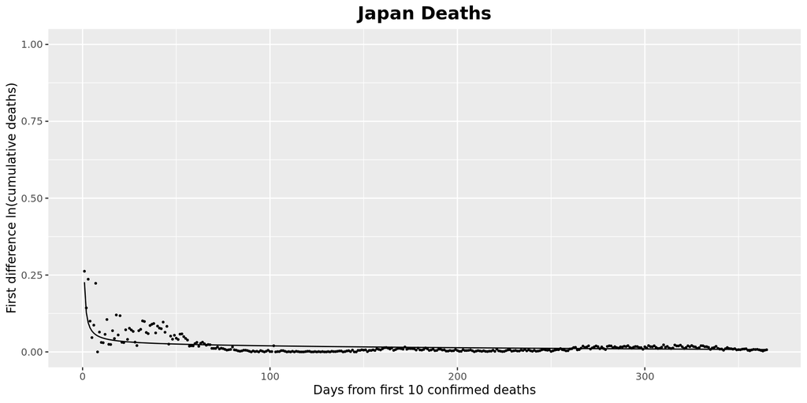

### South Korea

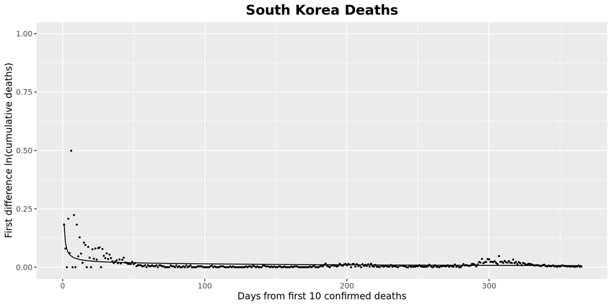

### Netherlands

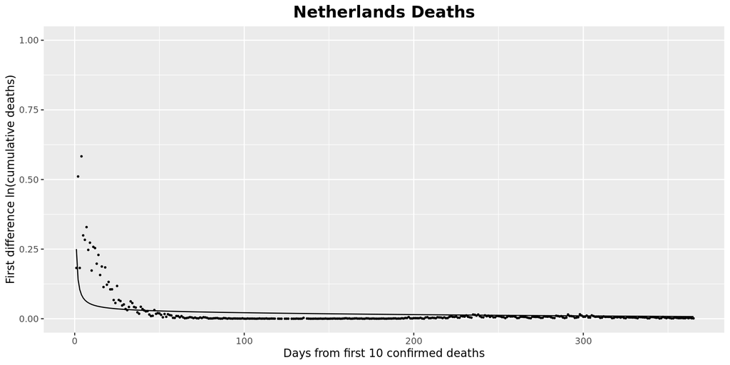